# Reddit Wordclouds with Python and R

Brian High

2015-05-14

This work is licensed under a [Creative Commons Attribution-ShareAlike 4.0 International License](http://creativecommons.org/licenses/by-sa/4.0/).

## Get word frequencies

To make a simple wordcloud of a Reddit forum (“subreddit”), we can use `word_freqs` from the reddit-analysis package to generate an output file of word frequencies. It uses the Reddit API to get data from the Reddit website.

```r
# Install reddit-analysis first: https://github.com/rhiever/reddit-analysis
# Replace USER with your own Reddit user name.
if (! file.exists("subreddit-publichealth.csv")){
    system("word_freqs /u/USER /r/publichealth", intern=TRUE)
}
```

## Install and load packages

We will install packages only if we don’t already have them.

```r
# Load required packages. Install packages when necessary.
for (pkg in c("RColorBrewer", "wordcloud")) {
    if (! suppressWarnings(require(pkg, character.only=TRUE))) {
        install.packages(pkg, repos="http://cran.fhcrc.org", dependencies=TRUE)
        if (! suppressWarnings(require(pkg, character.only=TRUE)) ) {
            stop(paste0(c("Can't load package: ", pkg, "!"), collapse = ""))
        }
    }
}
```

## Wordcloud function

It is very easy to make a wordcloud from the `word_freqs` output. Just import the data into a `data.frame` and run the `wordcloud` function on the word and frequency columns.

We will set a few other options with `par` and `title` to make the clouds nicer.

Wrapping this in a function will allow us to make clouds quickly and easily.

```r
wc <- function(subr){
    # Import only the first 100 rows (top 100 words)
    data <- read.table(file = paste0('subreddit-', subr, '.csv', collapse=''),
                        header = FALSE, sep = ':', stringsAsFactors = FALSE,
                        col.names = c("word", "freq"), nrows=100)

    # Use a black background, large bold white title text, and serif font
    par(bg = "black", col.main = "white", family = "serif",
        cex.main = 2, font.main = 2)

    # Use scale= to limit the size of the words so they will fit in the cloud
    wordcloud(data$word, data$freq, colors=brewer.pal(12, "Set3"),
              random.color = TRUE, scale=c(2.60, 0.70))

    # Set the title to the subreddit name
    title(paste0('/ r / ', subr, collapse=''))
}
```

## /r/publichealth

Try our first wordcloud.

```r
wc("publichealth")
```

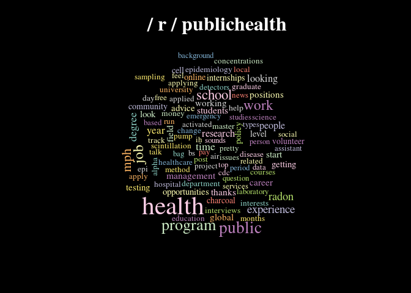

## More, more!

How about “bioinformatics”, “datascience”, “dataisbeautiful”, python“,”rstats“,”learnprogramming“, and”programming“?

```r
subs <- c("bioinformatics", "datascience", "dataisbeautiful", "python",
          "rstats", "learnprogramming", "programming")
```

Running `word_freqs` for all of these “subs” could take awhile…

```r
# Install reddit-analysis first: https://github.com/rhiever/reddit-analysis
# Replace USER with your own Reddit user name.
for (subr in subs) {
    if (! file.exists(paste0(c("subreddit-", subr, ".csv"), collapse=""))) {
        system(paste0(c("word_freqs /u/USER /r/", subr), collapse=""), intern=TRUE)
    }
}
```

We can generate all of them at once using `sapply`

```r
res <- sapply(subs, wc)
```

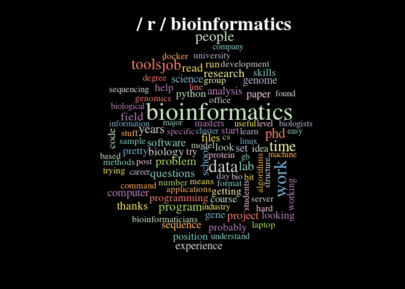

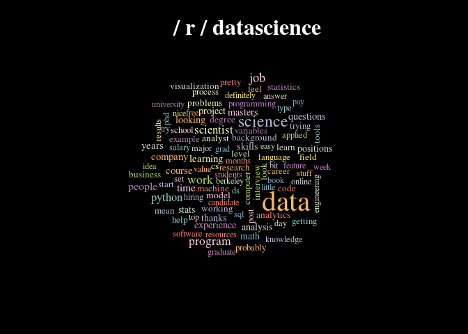

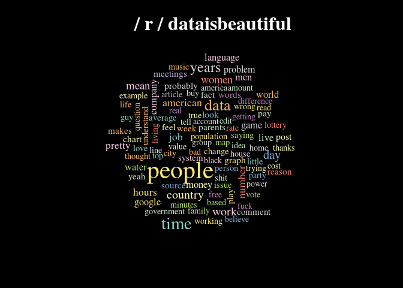

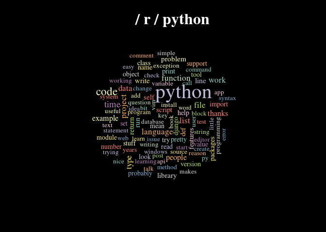

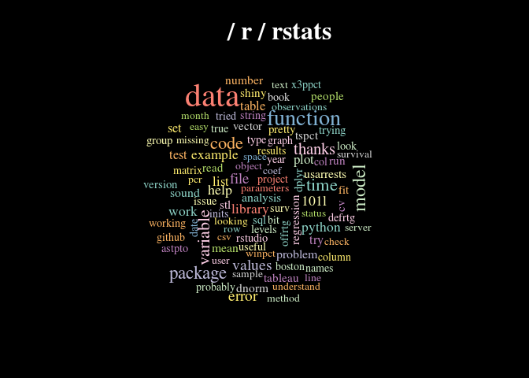

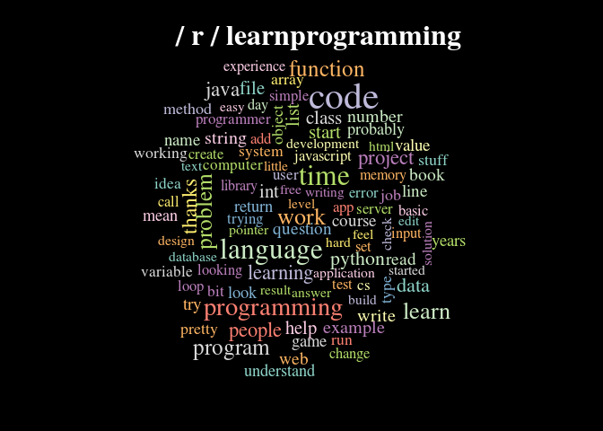

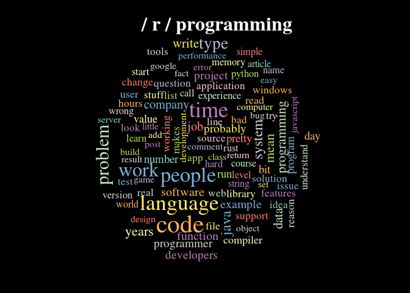